# Lecture 6: Linear Regression I

Sharon Tan

02 March 2021

## Preparation

*- Start by installing the packges you need. I will set message=FALSE and warning=FALSE so they will not show up in the HTML output.*

### Install Packages & Set Working Directory

```r
#install.packages("psych") #only need to run this code once to install the package

#library("rcompanion", lib.loc="~/Library/R/3.6/library") #this package is required for transformTukey function
#library("rstatix") # for Welch ANOVA & Games Howell test
#library("Rmisc") # For computation of CI
library("dplyr")
library("tidyr")
#library("rpivotTable")
#library("knitr")
#library("psych")

#put in your working directory folder pathname
setwd("~/Dropbox/Teaching/TBA2102/AY2021/Inclass Lecture/Lecture 6")
```

## Linear Regression on AirQuality

The dataset `airquality` contains daily readings of the following air quality values for May 1, 1973 (a Tuesday) to September 30, 1973.

- `Ozone`: Mean ozone in parts per billion from 1300 to 1500 hours at Roosevelt Island
- `Solar.R`: Solar radiation in Langleys in the frequency band 4000–7700 Angstroms from 0800 to 1200 hours at Central Park
- `Wind`: Average wind speed in miles per hour at 0700 and 1000 hours at LaGuardia Airport
- `Temp`: Maximum daily temperature in degrees Fahrenheit at La Guardia Airport.
- `Month`: Month of readings

*- Be sure to set working directory and import the datafile.*

```
## 'data.frame':    153 obs. of  6 variables:
##  $ Ozone  : int  41 36 12 18 NA 28 23 19 8 NA ...
##  $ Solar.R: int  190 118 149 313 NA NA 299 99 19 194 ...
##  $ Wind   : num  7.4 8 12.6 11.5 14.3 14.9 8.6 13.8 20.1 8.6 ...
##  $ Temp   : int  67 72 74 62 56 66 65 59 61 69 ...
##  $ Month  : int  5 5 5 5 5 5 5 5 5 5 ...
##  $ Day    : int  1 2 3 4 5 6 7 8 9 10 ...
```

#### Checking Data

*- Check that you have entered the data correctly by using the head() and summary() functions.*

```r
head(airquality)
```

```
##   Ozone Solar.R Wind Temp Month Day
## 1    41     190  7.4   67     5   1
## 2    36     118  8.0   72     5   2
## 3    12     149 12.6   74     5   3
## 4    18     313 11.5   62     5   4
## 5    NA      NA 14.3   56     5   5
## 6    28      NA 14.9   66     5   6
```

```r
summary(airquality)
```

```
##      Ozone           Solar.R           Wind             Temp
##  Min.   :  1.00   Min.   :  7.0   Min.   : 1.700   Min.   :56.00
##  1st Qu.: 18.00   1st Qu.:115.8   1st Qu.: 7.400   1st Qu.:72.00
##  Median : 31.50   Median :205.0   Median : 9.700   Median :79.00
##  Mean   : 42.13   Mean   :185.9   Mean   : 9.958   Mean   :77.88
##  3rd Qu.: 63.25   3rd Qu.:258.8   3rd Qu.:11.500   3rd Qu.:85.00
##  Max.   :168.00   Max.   :334.0   Max.   :20.700   Max.   :97.00
##  NA's   :37       NA's   :7
##      Month            Day
##  Min.   :5.000   Min.   : 1.0
##  1st Qu.:6.000   1st Qu.: 8.0
##  Median :7.000   Median :16.0
##  Mean   :6.993   Mean   :15.8
##  3rd Qu.:8.000   3rd Qu.:23.0
##  Max.   :9.000   Max.   :31.0
##
```

```r
str(airquality) #You can view this in the Global Environment window
```

```
## 'data.frame':    153 obs. of  6 variables:
##  $ Ozone  : int  41 36 12 18 NA 28 23 19 8 NA ...
##  $ Solar.R: int  190 118 149 313 NA NA 299 99 19 194 ...
##  $ Wind   : num  7.4 8 12.6 11.5 14.3 14.9 8.6 13.8 20.1 8.6 ...
##  $ Temp   : int  67 72 74 62 56 66 65 59 61 69 ...
##  $ Month  : int  5 5 5 5 5 5 5 5 5 5 ...
##  $ Day    : int  1 2 3 4 5 6 7 8 9 10 ...
```

#### Handling missing data

```r
# preprocess dataset to replace missing values NA with monthly average.

# apply function anyNA() on all columns of airquality dataset to check for presence of NA
col1<- mapply(anyNA,airquality)
col1
```

```
##   Ozone Solar.R    Wind    Temp   Month     Day
##    TRUE    TRUE   FALSE   FALSE   FALSE   FALSE
```

```r
# Impute monthly mean in Ozone to replace missing values NA
for (i in 1:nrow(airquality)){
  if(is.na(airquality[i,"Ozone"])){
    airquality[i,"Ozone"]<- mean(airquality[which(airquality[,"Month"]==airquality[i,"Month"]),"Ozone"],na.rm = TRUE)
  }
  # Impute monthly mean in Solar.R
  if(is.na(airquality[i,"Solar.R"])){
    airquality[i,"Solar.R"]<- mean(airquality[which(airquality[,"Month"]==airquality[i,"Month"]),"Solar.R"],na.rm = TRUE)
  }
}
```

#### Run linear regression

```r
#Run LRM using imputed data
Y<- airquality[,"Ozone"] # select Target attribute
X<- airquality[,"Solar.R"] # select Predictor attribute

model1<- lm(Y~X)
model1 # provides regression line coefficients i.e. slope and y-intercept
```

```
##
## Call:
## lm(formula = Y ~ X)
##
## Coefficients:
## (Intercept)            X
##    22.57801      0.09849
```

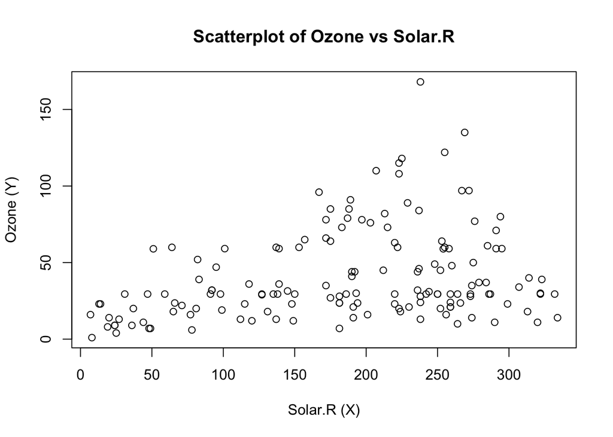

```r
plot(Y~X, xlab="Solar.R (X)", ylab="Ozone (Y)", main="Scatterplot of Ozone vs Solar.R")
```

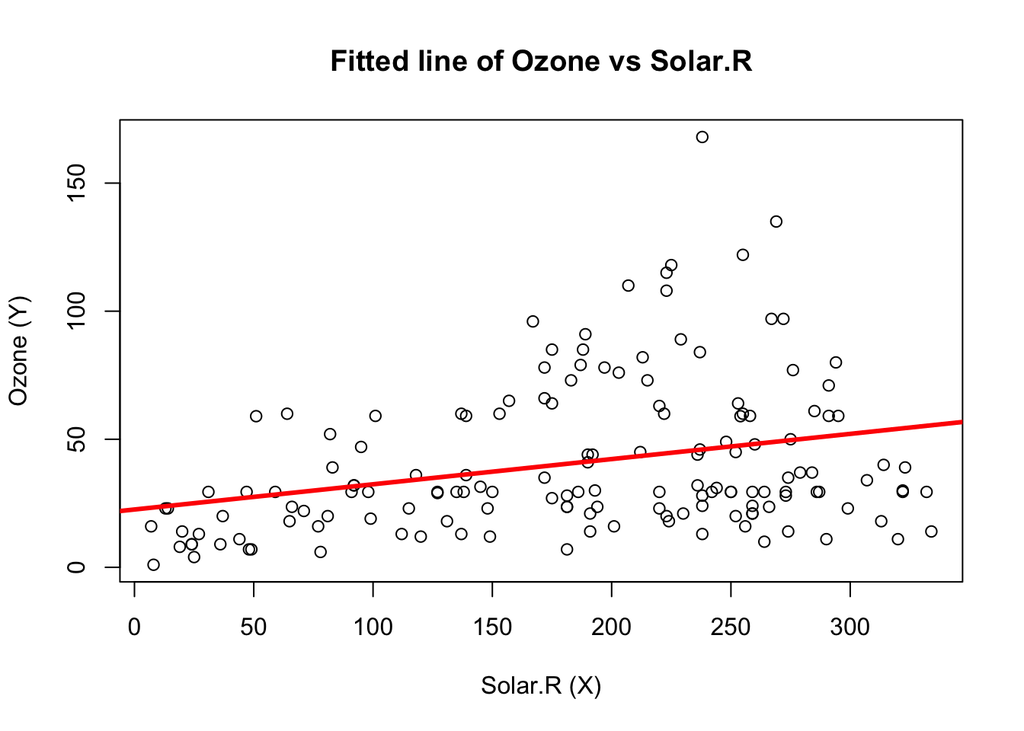

```r
plot(Y~X, xlab="Solar.R (X)", ylab="Ozone (Y)", main="Fitted line of Ozone vs Solar.R")
abline(model1, col="red", lwd=3)
```

```r
summary(model1)
```

```
##
## Call:
## lm(formula = Y ~ X)
##
## Residuals:
##     Min      1Q  Median      3Q     Max
## -43.095 -20.021  -7.571  15.065 121.981
##
## Coefficients:
##             Estimate Std. Error t value Pr(>|t|)
## (Intercept) 22.57801    5.37121   4.204 4.48e-05 ***
## X            0.09849    0.02617   3.763  0.00024 ***
## ---
## Signif. codes:  0 '***' 0.001 '**' 0.01 '*' 0.05 '.' 0.1 ' ' 1
##
## Residual standard error: 28.39 on 151 degrees of freedom
## Multiple R-squared:  0.08573,    Adjusted R-squared:  0.07968
## F-statistic: 14.16 on 1 and 151 DF,  p-value: 0.0002398
```

```r
#Checking OLS solution
b1<-cov(X,Y)/var(X)
b1
```

```
## [1] 0.09848987
```

```r
b0<-mean(Y) -b1 * mean(X)
b0
```

```
## [1] 22.57801
```

```r
# Checking Goodness of fit
# Generate anova table after fitting
aov.mod1<-aov(model1)
summary(aov.mod1)
```

```
##              Df Sum Sq Mean Sq F value  Pr(>F)
## X             1  11414   11414   14.16 0.00024 ***
## Residuals   151 121719     806
## ---
## Signif. codes:  0 '***' 0.001 '**' 0.01 '*' 0.05 '.' 0.1 ' ' 1
```

```r
r.sq<-11414/(11414+121719)
r.sq
```

```
## [1] 0.08573382
```

#### Checking linear regression assumptions

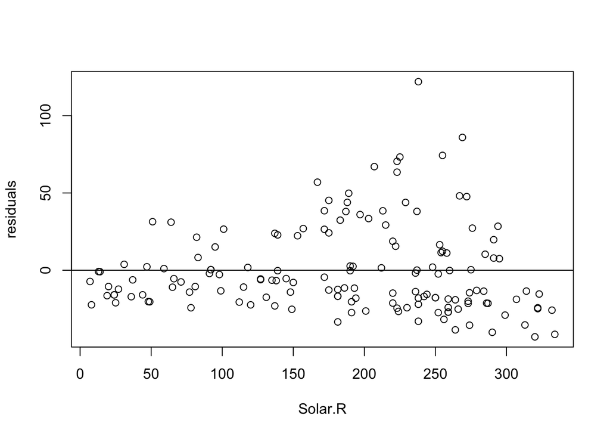

```r
#plotting the residuals
#recall earlier model1<-lm(X~Y)
airquality$residuals<-residuals(model1)
airquality$predicted<-predict(model1) #can also use fitted.values(model1)
plot(X,airquality$residuals,xlab="Solar.R", ylab="residuals")
abline(h=0)
```

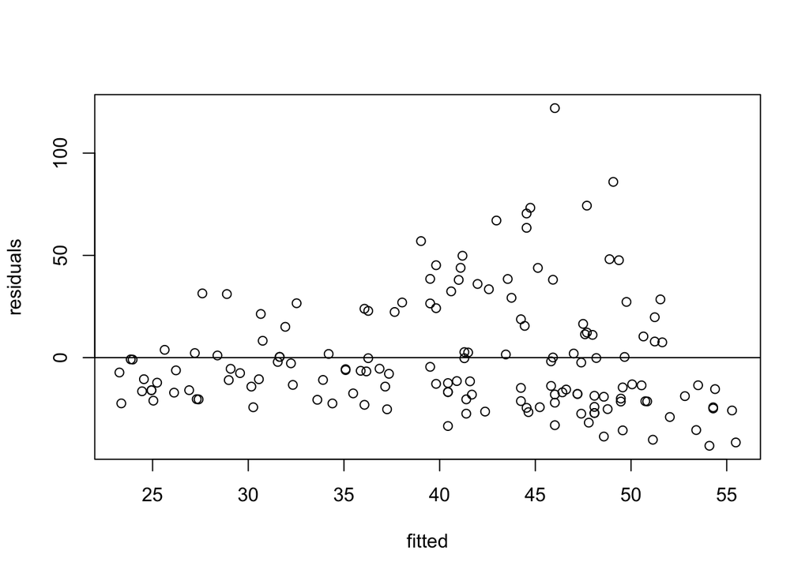

```r
plot(airquality$predicted,airquality$residuals,xlab="fitted", ylab="residuals")
abline(h=0)
```

#### Multiple Regression

```r
# Run IRM using IVs Solar.R and Wind
Y<- airquality[,"Ozone"]
X1<- airquality[,"Solar.R"]
X2<- airquality[,"Wind"]

model2<- lm(Y~X1+X2)
model2 # provides regression line coefficients i.e. slope and y-intercept
```

```
##
## Call:
## lm(formula = Y ~ X1 + X2)
##
## Coefficients:
## (Intercept)           X1           X2
##    66.27943      0.08963     -4.22375
```

#### Standardized Coefficients

```r
#Standardize the IV
standardize<- function(x){
  return((x-mean(x))/(sd(x)))
}
airquality$Solar.R.s<- standardize(airquality$Solar.R)
airquality$Wind.s<- standardize(airquality$Wind)
airquality$Ozone.s<-standardize(airquality$Ozone)
model3<-lm(airquality$Ozone.s~airquality$Solar.R.s+airquality$Wind.s)
model3 # how do you interpret the coefficients?
```

```
##
## Call:
## lm(formula = airquality$Ozone.s ~ airquality$Solar.R.s + airquality$Wind.s)
##
## Coefficients:
##          (Intercept)  airquality$Solar.R.s     airquality$Wind.s
##            6.338e-17             2.665e-01            -5.028e-01
```

## Logistic Regression on Titanic Data

The sinking of the Titanic is one of the most infamous shipwrecks in history. On April 15, 1912, during her maiden voyage, the widely considered “unsinkable” RMS Titanic sank after colliding with an iceberg. Unfortunately, there weren’t enough lifeboats for everyone onboard, resulting in the death of 1502 out of 2224 passengers and crew. The dataset `Titanic` contains data on some of the passengers and whether the passenger survived or not.

- `passengerid`: passenger identifier
- `survived`: survival; 0=NO; 1=YES
- `pclass`: ticket class; 1= 1st, 2=2nd, 3=3rd
- `name`: name of passenger
- `sex`: passenger gender
- `age`: age in years
- `sibsp`: # of siblings / spouses aboard the Titanic
- `parch`: # of parents / children aboard the Titanic
- `ticket`: Ticket number
- `fare`: Passenger fare
- `cabin`: cabin number
- `embarked`: Port of Embarkation; C = Cherbourg, Q = Queenstown, S = Southampton

```r
# read `titanic.csv`` file into data frame object `titanic`.
titanic = read.csv("titanic.csv", header = TRUE)
# use `glm()` with specified parameter `family = binomial` for logistic regression.
fit_surv = glm(survived ~ sex + age + sibsp + parch + fare +
                 embarked, family = binomial, data = titanic)
# display the output of logistic regression
summary(fit_surv)
```

```
##
## Call:
## glm(formula = survived ~ sex + age + sibsp + parch + fare + embarked,
##     family = binomial, data = titanic)
##
## Deviance Residuals:
##     Min       1Q   Median       3Q      Max
## -2.4061  -0.6454  -0.5270   0.7382   2.3798
##
## Coefficients:
##              Estimate Std. Error z value Pr(>|z|)
## (Intercept)  1.991142   0.335272   5.939 2.87e-09 ***
## sexmale     -2.635345   0.190231 -13.853  < 2e-16 ***
## age         -0.020467   0.007201  -2.842 0.004482 **
## sibsp       -0.394275   0.103822  -3.798 0.000146 ***
## parch       -0.222958   0.114051  -1.955 0.050595 .
## fare         0.014730   0.002849   5.170 2.34e-07 ***
## embarkedQ   -0.679104   0.362057  -1.876 0.060699 .
## embarkedS   -0.504620   0.226659  -2.226 0.025992 *
## ---
## Signif. codes:  0 '***' 0.001 '**' 0.01 '*' 0.05 '.' 0.1 ' ' 1
##
## (Dispersion parameter for binomial family taken to be 1)
##
##     Null deviance: 1182.82  on 888  degrees of freedom
## Residual deviance:  844.15  on 881  degrees of freedom
##   (2 observations deleted due to missingness)
## AIC: 860.15
##
## Number of Fisher Scoring iterations: 5
```